# Supervised Learning - Foundations Project: ReCell

### Log Transformation

The distribution of the weight column appears to be somewhat right-skewed, with a tail extending towards higher values. This suggests that a log transformation might help normalize the distribution by compressing the higher values and potentially making it more symmetric.

```python
# perform log transformation on the weight column and create a new column called weight_log

data_copy1['weight_log'] = np.log(data_copy1['weight'])
```

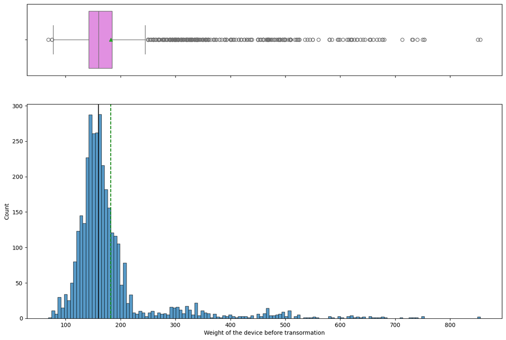

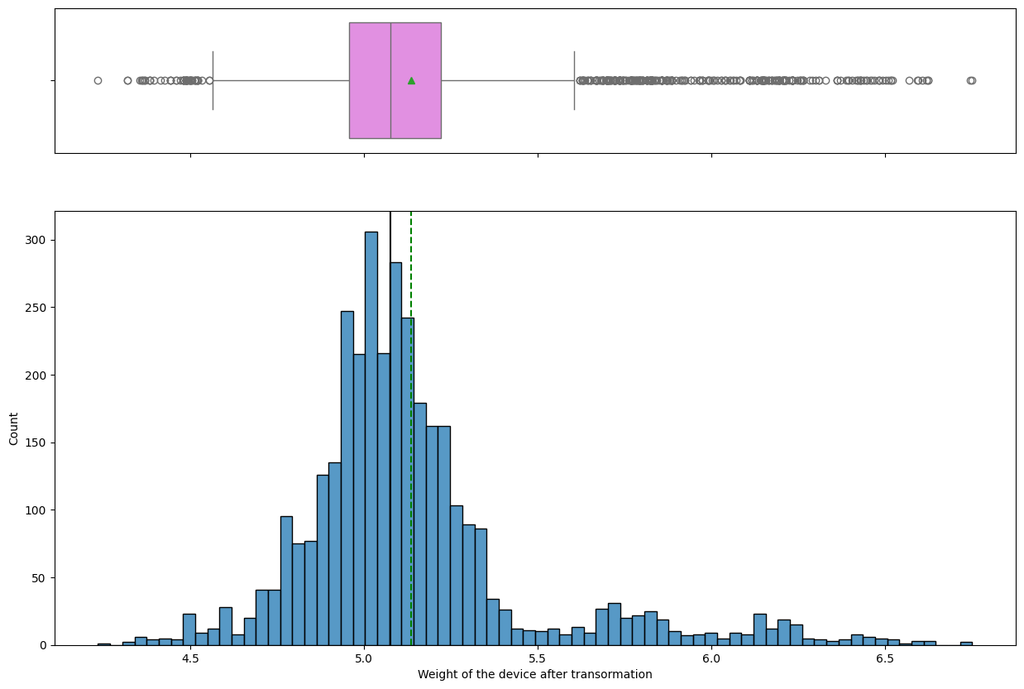

```python
# Lets compare the weight column distribution before and after the log transformation

histogram_boxplot(data_copy1, "weight")
plt.xlabel("Weight of the device before transormation");

histogram_boxplot(data_copy1, "weight_log")
plt.xlabel("Weight of the device after transormation");

plt.show();
```

- The log-transformed weight column now shows a distribution that is closer to symmetric and less skewed than before.
- We will go ahead and drop the weight column and leave the weight_log column

```python
data_copy1.drop(['weight'], axis=1, inplace=True)
```

### Data Preparation for Modeling

- We want to predict the price of the used/refurbished device
- Before we proceed to build a model, we'll have to encode categorical features
- We'll split the data into train and test to be able to evaluate the model that we build on the train data
- We will build a Linear Regression model using the train data and then check it's performance

```python
# define x (independent variable), y (dependent variable)
X = data_copy1.drop(['normalized_used_price'], axis=1)
y = data_copy1['normalized_used_price']
```

```python
# add intercept to the data
X = sm.add_constant(X)
```

```python
# create dummy variables
X = pd.get_dummies(X,
                  columns= X.select_dtypes(include=['object','category']).columns.tolist(),
                  drop_first=True,)

# converting the input attributes into float type for modeling
X = X.astype(float)

X.head()
```

|  | const | screen_size | main_camera_mp | selfie_camera_mp | int_memory | ram | battery | days_used | normalized_new_price | years_since_released | ... | brand_name_Spice | brand_name_Vivo | brand_name_XOLO | brand_name_Xiaomi | brand_name_ZTE | os_Others | os_Windows | os_iOS | 4g_yes | 5g_yes |
| --- | --- | --- | --- | --- | --- | --- | --- | --- | --- | --- | --- | --- | --- | --- | --- | --- | --- | --- | --- | --- | --- |
| 0 | 1.0 | 14.50 | 13.0 | 5.0 | 64.0 | 3.0 | 3020.0 | 127.0 | 4.715100 | 1.0 | ... | 0.0 | 0.0 | 0.0 | 0.0 | 0.0 | 0.0 | 0.0 | 0.0 | 1.0 | 0.0 |
| 1 | 1.0 | 17.30 | 13.0 | 16.0 | 128.0 | 8.0 | 4300.0 | 325.0 | 5.519018 | 1.0 | ... | 0.0 | 0.0 | 0.0 | 0.0 | 0.0 | 0.0 | 0.0 | 0.0 | 1.0 | 1.0 |
| 2 | 1.0 | 16.69 | 13.0 | 8.0 | 128.0 | 8.0 | 4200.0 | 162.0 | 5.884631 | 1.0 | ... | 0.0 | 0.0 | 0.0 | 0.0 | 0.0 | 0.0 | 0.0 | 0.0 | 1.0 | 1.0 |
| 3 | 1.0 | 19.30 | 13.0 | 8.0 | 64.0 | 6.0 | 6850.0 | 345.0 | 5.630961 | 1.0 | ... | 0.0 | 0.0 | 0.0 | 0.0 | 0.0 | 0.0 | 0.0 | 0.0 | 1.0 | 1.0 |
| 4 | 1.0 | 15.32 | 13.0 | 8.0 | 64.0 | 3.0 | 5000.0 | 293.0 | 4.947837 | 1.0 | ... | 0.0 | 0.0 | 0.0 | 0.0 | 0.0 | 0.0 | 0.0 | 0.0 | 1.0 | 0.0 |

5 rows × 49 columns

```python
# splitting the data into 70:30 ration for train to test data
X_train, X_test, y_train, y_test = train_test_split(X, y, test_size=0.3, random_state=1)
```

```python
print("Number of rows in train data =", X_train.shape[0])
print("Number of rows in test data =", X_test.shape[0])
```

```
Number of rows in train data = 2417
Number of rows in test data = 1037
```

## EDA

- It is a good idea to explore the data once again after manipulating it.

```python
# check the statistical summary once again
data_copy1.describe(include='all').T
```

|  | count | unique | top | freq | mean | std | min | 25% | 50% | 75% | max |
| --- | --- | --- | --- | --- | --- | --- | --- | --- | --- | --- | --- |
| brand_name | 3454 | 34 | Others | 502 | NaN | NaN | NaN | NaN | NaN | NaN | NaN |
| os | 3454 | 4 | Android | 3214 | NaN | NaN | NaN | NaN | NaN | NaN | NaN |
| screen_size | 3454.0 | NaN | NaN | NaN | 13.551595 | 2.807499 | 8.74 | 12.7 | 12.83 | 15.34 | 19.3 |
| 4g | 3454 | 2 | yes | 2335 | NaN | NaN | NaN | NaN | NaN | NaN | NaN |
| 5g | 3454 | 2 | no | 3302 | NaN | NaN | NaN | NaN | NaN | NaN | NaN |
| main_camera_mp | 3454.0 | NaN | NaN | NaN | 9.586329 | 4.572418 | 0.08 | 5.0 | 8.0 | 13.0 | 25.0 |
| selfie_camera_mp | 3454.0 | NaN | NaN | NaN | 5.96242 | 5.345927 | 0.0 | 2.0 | 5.0 | 8.0 | 17.0 |
| int_memory | 3454.0 | NaN | NaN | NaN | 44.694079 | 39.079988 | 0.01 | 16.0 | 32.0 | 64.0 | 136.0 |
| ram | 3454.0 | NaN | NaN | NaN | 4.03262 | 1.368598 | 0.02 | 4.0 | 4.0 | 4.0 | 12.0 |
| battery | 3454.0 | NaN | NaN | NaN | 3109.100898 | 1212.793754 | 500.0 | 2100.0 | 3000.0 | 4000.0 | 6850.0 |
| days_used | 3454.0 | NaN | NaN | NaN | 674.869716 | 248.580166 | 91.0 | 533.5 | 690.5 | 868.75 | 1094.0 |
| normalized_used_price | 3454.0 | NaN | NaN | NaN | 4.364712 | 0.588914 | 1.536867 | 4.033931 | 4.405133 | 4.7557 | 6.619433 |
| normalized_new_price | 3454.0 | NaN | NaN | NaN | 5.234936 | 0.666538 | 3.465277 | 4.790342 | 5.245892 | 5.673718 | 6.998783 |
| years_since_released | 3454.0 | NaN | NaN | NaN | 5.034742 | 2.298455 | 1.0 | 3.0 | 5.5 | 7.0 | 8.0 |
| weight_log | 3454.0 | NaN | NaN | NaN | 5.135866 | 0.342228 | 4.234107 | 4.955827 | 5.075174 | 5.220356 | 6.751101 |

```python
# check if there are any missing values
data_copy1.isnull().sum()
```

|  | 0 |
| --- | --- |
| brand_name | 0 |
| os | 0 |
| screen_size | 0 |
| 4g | 0 |
| 5g | 0 |
| main_camera_mp | 0 |
| selfie_camera_mp | 0 |
| int_memory | 0 |
| ram | 0 |
| battery | 0 |
| days_used | 0 |
| normalized_used_price | 0 |
| normalized_new_price | 0 |
| years_since_released | 0 |
| weight_log | 0 |

**dtype:** int64

## Model Building - Linear Regression

```python
olsmodel = sm.OLS(y_train, X_train).fit()
print(olsmodel.summary())
```

```
                              OLS Regression Results
=================================================================================
Dep. Variable:     normalized_used_price   R-squared:                       0.844
Model:                               OLS   Adj. R-squared:                  0.841
Method:                    Least Squares   F-statistic:                     266.8
Date:                   Sat, 09 Nov 2024   Prob (F-statistic):               0.00
Time:                           02:01:29   Log-Likelihood:                 116.71
No. Observations:                   2417   AIC:                            -135.4
Df Residuals:                       2368   BIC:                             148.3
Df Model:                             48
Covariance Type:               nonrobust
=========================================================================================
                            coef    std err          t      P>|t|      [0.025      0.975]
-----------------------------------------------------------------------------------------
const                    -0.2839      0.131     -2.165      0.030      -0.541      -0.027
screen_size               0.0279      0.004      7.139      0.000       0.020       0.036
main_camera_mp            0.0237      0.002     14.232      0.000       0.020       0.027
selfie_camera_mp          0.0181      0.002     10.206      0.000       0.015       0.022
int_memory                0.0006      0.000      3.295      0.001       0.000       0.001
ram                       0.0259      0.005      5.075      0.000       0.016       0.036
battery               -2.239e-05   7.84e-06     -2.857      0.004   -3.78e-05   -7.02e-06
days_used              4.732e-05    3.1e-05      1.526      0.127   -1.35e-05       0.000
normalized_new_price      0.3997      0.013     29.996      0.000       0.374       0.426
years_since_released     -0.0120      0.005     -2.467      0.014      -0.021      -0.002
weight_log                0.3477      0.031     11.090      0.000       0.286       0.409
brand_name_Alcatel        0.0234      0.048      0.490      0.624      -0.070       0.117
brand_name_Apple          0.2360      0.147      1.602      0.109      -0.053       0.525
brand_name_Asus           0.0021      0.048      0.043      0.966      -0.092       0.096
brand_name_BlackBerry    -0.0119      0.071     -0.168      0.866      -0.150       0.127
brand_name_Celkon        -0.0873      0.067     -1.301      0.193      -0.219       0.044
brand_name_Coolpad        0.0113      0.073      0.154      0.877      -0.132       0.155
brand_name_Gionee         0.0370      0.058      0.639      0.523      -0.077       0.151
brand_name_Google        -0.0184      0.085     -0.216      0.829      -0.185       0.148
brand_name_HTC           -0.0152      0.048     -0.314      0.754      -0.110       0.080
brand_name_Honor          0.0241      0.049      0.488      0.625      -0.073       0.121
brand_name_Huawei        -0.0011      0.045     -0.024      0.981      -0.089       0.086
brand_name_Infinix        0.1395      0.094      1.491      0.136      -0.044       0.323
brand_name_Karbonn        0.0930      0.067      1.380      0.168      -0.039       0.225
brand_name_LG             0.0019      0.045      0.041      0.967      -0.087       0.091
brand_name_Lava           0.0410      0.063      0.656      0.512      -0.082       0.164
```

[output cut: 19 more lines]

```
os_Windows               -0.0196      0.045     -0.433      0.665      -0.109       0.069
os_iOS                   -0.2494      0.146     -1.708      0.088      -0.536       0.037
4g_yes                    0.0410      0.016      2.549      0.011       0.009       0.072
5g_yes                   -0.0514      0.032     -1.632      0.103      -0.113       0.010
==============================================================================
Omnibus:                      202.730   Durbin-Watson:                   1.934
Prob(Omnibus):                  0.000   Jarque-Bera (JB):              404.665
Skew:                          -0.554   Prob(JB):                     1.34e-88
Kurtosis:                       4.670   Cond. No.                     1.76e+05
==============================================================================

Notes:
[1] Standard Errors assume that the covariance matrix of the errors is correctly specified.
[2] The condition number is large, 1.76e+05. This might indicate that there are
strong multicollinearity or other numerical problems.
```

1. **Adjusted. R-squared**: It reflects the fit of the model.
   - Adjusted R-squared values generally range from 0 to 1, where a higher value generally indicates a better fit, assuming certain conditions are met.
   - In our case, the value for adj. R-squared is **0.841**, which is good.
1. *const* coefficient: It is the Y-intercept.
   - It means that if all the predictor variable coefficients are zero, then the expected output (i.e., Y) would be equal to the *const* coefficient.
   - In our case, the value for `const` coefficient is **-0.2839**
1. **Coefficient of a predictor variable**: It represents the change in the output Y due to a change in the predictor variable (everything else held constant).
   - EX: In our case, the coefficient of screen_size is **0.027**.
2. The training R2 is 84.0%, indicating that the model explains 84.0 % of the variation in the train data; therefore, I can conclude the model is not underfitting

## Model Performance Check

Let's check the performance of the model using different metrics.

- We will be using metric functions defined in sklearn for RMSE, MAE, and $R^2$.
- We will define a function to calculate MAPE and adjusted $R^2$.
  - The mean absolute percentage error (MAPE) measures the accuracy of predictions as a percentage, and can be calculated as the average absolute percent error for each predicted value minus actual values divided by actual values. It works best if there are no extreme values in the data and none of the actual values are 0.
- We will create a function which will print out all the above metrics.

```python
# function to compute adjusted R-squared
def adj_r2_score(predictors, targets, predictions):
    r2 = r2_score(targets, predictions)
    n = predictors.shape[0]
    k = predictors.shape[1]
    return 1 - ((1 - r2) * (n - 1) / (n - k - 1))


# function to compute MAPE
def mape_score(targets, predictions):
    return np.mean(np.abs(targets - predictions) / targets) * 100


# function to compute different metrics to check performance of a regression model
def model_performance_regression(model, predictors, target):
    """
    Function to compute different metrics to check regression model performance

    model: regressor
    predictors: independent variables
    target: dependent variable
    """

    # predicting using the independent variables
    pred = model.predict(predictors)

    r2 = r2_score(target, pred)  # to compute R-squared
    adjr2 = adj_r2_score(predictors, target, pred)  # to compute adjusted R-squared
    rmse = np.sqrt(mean_squared_error(target, pred))  # to compute RMSE
    mae = mean_absolute_error(target, pred)  # to compute MAE
    mape = mape_score(target, pred)  # to compute MAPE

    # creating a dataframe of metrics
    df_perf = pd.DataFrame(
        {
            "RMSE": rmse,
            "MAE": mae,
            "R-squared": r2,
            "Adj. R-squared": adjr2,
            "MAPE": mape,
        },
        index=[0],
    )

    return df_perf
```

```python
# checking the model performance on the train set
olsmodel_train_performance = model_performance_regression(olsmodel, X_train, y_train)
olsmodel_train_performance
```

|  | RMSE | MAE | R-squared | Adj. R-squared | MAPE |
| --- | --- | --- | --- | --- | --- |
| 0 | 0.230564 | 0.178715 | 0.843967 | 0.840736 | 4.300546 |

```python
# checking the model performance on the test set
olsmodel_test_performance = model_performance_regression(olsmodel, X_test, y_test)
olsmodel_test_performance
```

|  | RMSE | MAE | R-squared | Adj. R-squared | MAPE |
| --- | --- | --- | --- | --- | --- |
| 0 | 0.241003 | 0.185686 | 0.838964 | 0.830969 | 4.530851 |

- The Adjusted R-square for the Training set is 0.84 and the same for Testing set is 0.83, since the difference is very small, we can conclude that there has been no overfitting
- The RMSE of both training and testing performance show a minute difference hence proving our claim of no overfitting
- MAPE of 4.5 on the test data indicates that the model can predict within 4.5% of the normalized used phone price.

## Checking Linear Regression Assumptions

In order to make statistical inferences from a linear regression model, it is important to ensure that the assumptions of linear regression are satisfied. We will be checking the following Linear Regression assumptions:

1. **No Multicollinearity**
2. **Linearity of variables**
3. **Independence of error terms**
4. **Normality of error terms**
5. **No Heteroscedasticity**

### TEST FOR MULTICOLLINEARITY

- Multicollinearity occurs when predictor variables in a regression model are correlated. This correlation is a problem because predictor variables should be independent. If the correlation between variables is high, it can cause problems when we fit the model and interpret the results. When we have multicollinearity in the linear model, the coefficients that the model suggests are unreliable.
- There are different ways of detecting (or testing) multicollinearity. One such way is by using the Variance Inflation Factor, or VIF.
- **Variance Inflation Factor (VIF)**: Variance inflation factors measure the inflation in the variances of the regression parameter estimates due to collinearities that exist among the predictors. It is a measure of how much the variance of the estimated regression coefficient $\beta_k$ is "inflated" by the existence of correlation among the predictor variables in the model.
  - If VIF is 1, then there is no correlation among the $k$th predictor and the remaining predictor variables, and hence, the variance of $\beta_k$ is not inflated at all.
- **General Rule of thumb**:
  - If VIF is between 1 and 5, then there is low multicollinearity.
  - If VIF is between 5 and 10, we say there is moderate multicollinearity.
  - If VIF is exceeding 10, it shows signs of high multicollinearity.

```python
# calculating the VIF

def calculate_vif(predictors):
    vif = pd.DataFrame()
    vif["variables"] = predictors.columns

# calculating
    vif["VIF"] = [
        variance_inflation_factor(predictors.values, i)
        for i in range(len(predictors.columns))]

    return vif
```

```python
calculate_vif(X_train)
```

|  | variables | VIF |
| --- | --- | --- |
| 0 | const | 765.851231 |
| 1 | screen_size | 5.497122 |
| 2 | main_camera_mp | 2.540285 |
| 3 | selfie_camera_mp | 3.982305 |
| 4 | int_memory | 2.504370 |
| 5 | ram | 2.223633 |
| 6 | battery | 4.117452 |
| 7 | days_used | 2.668102 |
| 8 | normalized_new_price | 3.466852 |
| 9 | years_since_released | 5.516305 |
| 10 | weight_log | 5.330395 |
| 11 | brand_name_Alcatel | 3.410547 |
| 12 | brand_name_Apple | 13.005770 |
| 13 | brand_name_Asus | 3.331932 |
| 14 | brand_name_BlackBerry | 1.643765 |
| 15 | brand_name_Celkon | 1.810344 |
| 16 | brand_name_Coolpad | 1.469715 |
| 17 | brand_name_Gionee | 1.950275 |
| 18 | brand_name_Google | 1.323434 |
| 19 | brand_name_HTC | 3.417459 |
| 20 | brand_name_Honor | 3.349741 |
| 21 | brand_name_Huawei | 5.987877 |
| 22 | brand_name_Infinix | 1.286595 |
| 23 | brand_name_Karbonn | 1.578335 |
| 24 | brand_name_LG | 4.855775 |
| 25 | brand_name_Lava | 1.711216 |
| 26 | brand_name_Lenovo | 4.555971 |
| 27 | brand_name_Meizu | 2.185860 |
| 28 | brand_name_Micromax | 3.358567 |
| 29 | brand_name_Microsoft | 1.869357 |
| 30 | brand_name_Motorola | 3.270828 |
| 31 | brand_name_Nokia | 3.497655 |
| 32 | brand_name_OnePlus | 1.441413 |
| 33 | brand_name_Oppo | 3.960565 |
| 34 | brand_name_Others | 9.712178 |
| 35 | brand_name_Panasonic | 2.107202 |
| 36 | brand_name_Realme | 1.948998 |
| 37 | brand_name_Samsung | 7.553349 |
| 38 | brand_name_Sony | 2.957490 |
| 39 | brand_name_Spice | 1.692117 |
| 40 | brand_name_Vivo | 3.669239 |
| 41 | brand_name_XOLO | 2.142615 |
| 42 | brand_name_Xiaomi | 3.729916 |
| 43 | brand_name_ZTE | 3.799591 |
| 44 | os_Others | 1.691325 |
| 45 | os_Windows | 1.601748 |
| 46 | os_iOS | 11.639278 |
| 47 | 4g_yes | 2.517375 |
| 48 | 5g_yes | 1.804128 |

- There are multiple columns with very high VIF values, indicating presence of strong multicollinearity
- We will systematically drop numerical columns with VIF > 5
- We will ignore the VIF values for dummy variables and the constant (intercept)

### Removing Multicollinearity

To remove multicollinearity

1. Drop every column one by one that has a VIF score greater than 5.
2. Look at the adjusted R-squared and RMSE of all these models.
3. Drop the variable that makes the least change in adjusted R-squared.
4. Check the VIF scores again.
5. Continue till you get all VIF scores under 5.

Below is a function that will help us do this

```python
def treating_multicollinearity(predictors, target, high_vif_columns):
    """
    Checking the effect of dropping the columns showing high multicollinearity
    on model performance (adj. R-squared and RMSE)

    predictors: independent variables
    target: dependent variable
    high_vif_columns: columns having high VIF
    """
    # empty lists to store adj. R-squared and RMSE values
    adj_r2 = []
    rmse = []

    # build ols models by dropping one of the high VIF columns at a time
    # store the adjusted R-squared and RMSE in the lists defined previously
    for cols in high_vif_columns:
        # defining the new train set
        train = predictors.loc[:, ~predictors.columns.str.startswith(cols)]

        # create the model
        olsmodel = sm.OLS(target, train).fit()

        # adding adj. R-squared and RMSE to the lists
        adj_r2.append(olsmodel.rsquared_adj)
        rmse.append(np.sqrt(olsmodel.mse_resid))

    # creating a dataframe for the results
    temp = pd.DataFrame(
        {
            "col": high_vif_columns,
            "Adj. R-squared after_dropping col": adj_r2,
            "RMSE after dropping col": rmse,
        }
    ).sort_values(by="Adj. R-squared after_dropping col", ascending=False)
    temp.reset_index(drop=True, inplace=True)

    return temp
```

```python
col_list = [
    "screen-size",
    "weight_log","years_since_released"]

response = treating_multicollinearity(X_train, y_train, col_list)
response
```

|  | col | Adj. R-squared after_dropping col | RMSE after dropping col |
| --- | --- | --- | --- |
| 0 | screen-size | 0.840804 | 0.232937 |
| 1 | years_since_released | 0.840462 | 0.233187 |
| 2 | weight_log | 0.832606 | 0.238859 |

```python
# Dropping years_since_released has the least effect on adj r2 and rmse so dropping it and calculating VIF again

col_to_drop = "years_since_released"
X_train2 = X_train.loc[:, ~X_train.columns.str.startswith(col_to_drop)]
X_test2 = X_test.loc[:, ~X_test.columns.str.startswith(col_to_drop)]

# Check VIF now
vif = calculate_vif(X_train2)
print("VIF after dropping ", col_to_drop)
vif
```

```
VIF after dropping  years_since_released
```

|  | variables | VIF |
| --- | --- | --- |
| 0 | const | 765.086819 |
| 1 | screen_size | 5.367367 |
| 2 | main_camera_mp | 2.525203 |
| 3 | selfie_camera_mp | 3.476231 |
| 4 | int_memory | 2.407872 |
| 5 | ram | 2.220846 |
| 6 | battery | 4.009673 |
| 7 | days_used | 2.011293 |
| 8 | normalized_new_price | 3.085291 |
| 9 | weight_log | 5.268524 |
| 10 | brand_name_Alcatel | 3.409654 |
| 11 | brand_name_Apple | 12.913022 |
| 12 | brand_name_Asus | 3.331831 |
| 13 | brand_name_BlackBerry | 1.643644 |
| 14 | brand_name_Celkon | 1.796752 |
| 15 | brand_name_Coolpad | 1.469294 |
| 16 | brand_name_Gionee | 1.950245 |
| 17 | brand_name_Google | 1.315634 |
| 18 | brand_name_HTC | 3.417363 |
| 19 | brand_name_Honor | 3.349148 |
| 20 | brand_name_Huawei | 5.987706 |
| 21 | brand_name_Infinix | 1.286324 |
| 22 | brand_name_Karbonn | 1.572551 |
| 23 | brand_name_LG | 4.853824 |
| 24 | brand_name_Lava | 1.711216 |
| 25 | brand_name_Lenovo | 4.555591 |
| 26 | brand_name_Meizu | 2.185285 |
| 27 | brand_name_Micromax | 3.358520 |
| 28 | brand_name_Microsoft | 1.864382 |
| 29 | brand_name_Motorola | 3.269615 |
| 30 | brand_name_Nokia | 3.459725 |
| 31 | brand_name_OnePlus | 1.441228 |
| 32 | brand_name_Oppo | 3.960113 |
| 33 | brand_name_Others | 9.709485 |
| 34 | brand_name_Panasonic | 2.106343 |
| 35 | brand_name_Realme | 1.946614 |
| 36 | brand_name_Samsung | 7.550243 |
| 37 | brand_name_Sony | 2.957341 |
| 38 | brand_name_Spice | 1.689076 |
| 39 | brand_name_Vivo | 3.668587 |
| 40 | brand_name_XOLO | 2.141846 |
| 41 | brand_name_Xiaomi | 3.729408 |
| 42 | brand_name_ZTE | 3.799238 |
| 43 | os_Others | 1.683648 |
| 44 | os_Windows | 1.594463 |
| 45 | os_iOS | 11.612431 |
| 46 | 4g_yes | 2.193690 |
| 47 | 5g_yes | 1.780858 |

```python
col_list = [
    "screen-size",
    "weight_log"]

response = treating_multicollinearity(X_train, y_train, col_list)
response
```

|  | col | Adj. R-squared after_dropping col | RMSE after dropping col |
| --- | --- | --- | --- |
| 0 | screen-size | 0.840804 | 0.232937 |
| 1 | weight_log | 0.832606 | 0.238859 |

```python
col_to_drop = "screen_size"
X_train3 = X_train2.loc[:, ~X_train2.columns.str.startswith(col_to_drop)]
X_test3 = X_test2.loc[:, ~X_test2.columns.str.startswith(col_to_drop)]

# Check VIF now
vif = calculate_vif(X_train3)
print("VIF after dropping ", col_to_drop)
vif
```

```
VIF after dropping  screen_size
```

|  | variables | VIF |
| --- | --- | --- |
| 0 | const | 643.238035 |
| 1 | main_camera_mp | 2.524279 |
| 2 | selfie_camera_mp | 3.388188 |
| 3 | int_memory | 2.407805 |
| 4 | ram | 2.219653 |
| 5 | battery | 3.801085 |
| 6 | days_used | 1.949414 |
| 7 | normalized_new_price | 3.084911 |
| 8 | weight_log | 3.128427 |
| 9 | brand_name_Alcatel | 3.409017 |
| 10 | brand_name_Apple | 12.889708 |
| 11 | brand_name_Asus | 3.328242 |
| 12 | brand_name_BlackBerry | 1.629326 |
| 13 | brand_name_Celkon | 1.792368 |
| 14 | brand_name_Coolpad | 1.469019 |
| 15 | brand_name_Gionee | 1.939244 |
| 16 | brand_name_Google | 1.314726 |
| 17 | brand_name_HTC | 3.405431 |
| 18 | brand_name_Honor | 3.348498 |
| 19 | brand_name_Huawei | 5.984669 |
| 20 | brand_name_Infinix | 1.286020 |
| 21 | brand_name_Karbonn | 1.572422 |
| 22 | brand_name_LG | 4.838203 |
| 23 | brand_name_Lava | 1.710196 |
| 24 | brand_name_Lenovo | 4.551856 |
| 25 | brand_name_Meizu | 2.182709 |
| 26 | brand_name_Micromax | 3.353125 |
| 27 | brand_name_Microsoft | 1.864150 |
| 28 | brand_name_Motorola | 3.259009 |
| 29 | brand_name_Nokia | 3.458164 |
| 30 | brand_name_OnePlus | 1.441227 |
| 31 | brand_name_Oppo | 3.954337 |
| 32 | brand_name_Others | 9.656978 |
| 33 | brand_name_Panasonic | 2.105524 |
| 34 | brand_name_Realme | 1.945086 |
| 35 | brand_name_Samsung | 7.531559 |
| 36 | brand_name_Sony | 2.947778 |
| 37 | brand_name_Spice | 1.680839 |
| 38 | brand_name_Vivo | 3.668346 |
| 39 | brand_name_XOLO | 2.141725 |
| 40 | brand_name_Xiaomi | 3.725201 |
| 41 | brand_name_ZTE | 3.788813 |
| 42 | os_Others | 1.654948 |
| 43 | os_Windows | 1.593044 |
| 44 | os_iOS | 11.611021 |
| 45 | 4g_yes | 2.191466 |
| 46 | 5g_yes | 1.780776 |

```python
# Let us check the model summary again
olsmod1 = sm.OLS(y_train, X_train3).fit()
print(olsmod1.summary())
```

```
                              OLS Regression Results
=================================================================================
Dep. Variable:     normalized_used_price   R-squared:                       0.840
Model:                               OLS   Adj. R-squared:                  0.837
Method:                    Least Squares   F-statistic:                     270.0
Date:                   Sat, 09 Nov 2024   Prob (F-statistic):               0.00
Time:                           02:01:32   Log-Likelihood:                 84.494
No. Observations:                   2417   AIC:                            -74.99
Df Residuals:                       2370   BIC:                             197.2
Df Model:                             46
Covariance Type:               nonrobust
=========================================================================================
                            coef    std err          t      P>|t|      [0.025      0.975]
-----------------------------------------------------------------------------------------
const                    -0.6716      0.122     -5.517      0.000      -0.910      -0.433
main_camera_mp            0.0243      0.002     14.426      0.000       0.021       0.028
selfie_camera_mp          0.0217      0.002     13.074      0.000       0.018       0.025
int_memory                0.0007      0.000      3.845      0.000       0.000       0.001
ram                       0.0246      0.005      4.754      0.000       0.014       0.035
battery               -5.843e-06   7.63e-06     -0.766      0.444   -2.08e-05    9.12e-06
days_used             -2.655e-05   2.68e-05     -0.989      0.323   -7.92e-05    2.61e-05
normalized_new_price      0.3899      0.013     30.618      0.000       0.365       0.415
weight_log                0.4905      0.024     20.160      0.000       0.443       0.538
brand_name_Alcatel        0.0303      0.048      0.626      0.531      -0.065       0.125
brand_name_Apple          0.2192      0.148      1.476      0.140      -0.072       0.510
brand_name_Asus          -0.0093      0.049     -0.190      0.849      -0.105       0.086
brand_name_BlackBerry    -0.0636      0.071     -0.892      0.372      -0.203       0.076
brand_name_Celkon        -0.1268      0.068     -1.874      0.061      -0.259       0.006
brand_name_Coolpad        0.0067      0.074      0.091      0.928      -0.139       0.152
brand_name_Gionee         0.0033      0.058      0.057      0.954      -0.111       0.118
brand_name_Google        -0.0192      0.086     -0.224      0.823      -0.187       0.149
brand_name_HTC           -0.0376      0.049     -0.768      0.443      -0.133       0.058
brand_name_Honor          0.0310      0.050      0.619      0.536      -0.067       0.129
brand_name_Huawei        -0.0081      0.045     -0.180      0.857      -0.097       0.080
brand_name_Infinix        0.1319      0.095      1.392      0.164      -0.054       0.318
brand_name_Karbonn        0.0876      0.068      1.285      0.199      -0.046       0.221
brand_name_LG            -0.0155      0.046     -0.337      0.736      -0.106       0.075
brand_name_Lava           0.0294      0.063      0.464      0.643      -0.095       0.153
brand_name_Lenovo         0.0270      0.046      0.587      0.557      -0.063       0.117
brand_name_Meizu         -0.0444      0.057     -0.779      0.436      -0.156       0.067
```

[output cut: 17 more lines]

```
os_Windows               -0.0374      0.046     -0.817      0.414      -0.127       0.052
os_iOS                   -0.2545      0.148     -1.723      0.085      -0.544       0.035
4g_yes                    0.0588      0.015      3.872      0.000       0.029       0.089
5g_yes                   -0.0410      0.032     -1.293      0.196      -0.103       0.021
==============================================================================
Omnibus:                      198.482   Durbin-Watson:                   1.933
Prob(Omnibus):                  0.000   Jarque-Bera (JB):              387.278
Skew:                          -0.551   Prob(JB):                     8.01e-85
Kurtosis:                       4.622   Cond. No.                     1.76e+05
==============================================================================

Notes:
[1] Standard Errors assume that the covariance matrix of the errors is correctly specified.
[2] The condition number is large, 1.76e+05. This might indicate that there are
strong multicollinearity or other numerical problems.
```

We can see that now after treating Multicollinearity, the Adjusted R-square has dropped from 0.84 to 0.837

### Dropping high p-value variables

```python
# initial list of columns
predictors = X_train3.copy()
cols = predictors.columns.tolist()

# setting an initial max p-value
max_p_value = 1

while len(cols) > 0:
    # defining the train set
    X_train_aux = predictors[cols]

    # fitting the model
    model = sm.OLS(y_train, X_train_aux).fit()

    # getting the p-values and the maximum p-value
    p_values = model.pvalues
    max_p_value = max(p_values)

    # name of the variable with maximum p-value
    feature_with_p_max = p_values.idxmax()

    if max_p_value > 0.05:
        cols.remove(feature_with_p_max)
    else:
        break

selected_features = cols
print(selected_features)
```

```
['const', 'main_camera_mp', 'selfie_camera_mp', 'int_memory', 'ram', 'normalized_new_price', 'weight_log', 'brand_name_Celkon', 'brand_name_Micromax', 'brand_name_Nokia', 'brand_name_Others', 'brand_name_Sony', 'os_Others', '4g_yes']
```

```python
X_train4 = X_train3[selected_features]
X_test4 = X_test3[selected_features]
```

```python
olsmod_afterP = sm.OLS(y_train, X_train4).fit()
print(olsmod_afterP.summary())
```

```
                              OLS Regression Results
=================================================================================
Dep. Variable:     normalized_used_price   R-squared:                       0.837
Model:                               OLS   Adj. R-squared:                  0.836
Method:                    Least Squares   F-statistic:                     951.5
Date:                   Sat, 09 Nov 2024   Prob (F-statistic):               0.00
Time:                           02:01:32   Log-Likelihood:                 66.343
No. Observations:                   2417   AIC:                            -104.7
Df Residuals:                       2403   BIC:                            -23.62
Df Model:                             13
Covariance Type:               nonrobust
========================================================================================
                           coef    std err          t      P>|t|      [0.025      0.975]
----------------------------------------------------------------------------------------
const                   -0.6191      0.078     -7.888      0.000      -0.773      -0.465
main_camera_mp           0.0246      0.002     15.697      0.000       0.022       0.028
selfie_camera_mp         0.0219      0.002     14.580      0.000       0.019       0.025
int_memory               0.0008      0.000      4.420      0.000       0.000       0.001
ram                      0.0222      0.004      4.950      0.000       0.013       0.031
normalized_new_price     0.3764      0.011     33.501      0.000       0.354       0.398
weight_log               0.4872      0.016     31.236      0.000       0.457       0.518
brand_name_Celkon       -0.1380      0.054     -2.552      0.011      -0.244      -0.032
brand_name_Micromax     -0.0656      0.028     -2.367      0.018      -0.120      -0.011
brand_name_Nokia         0.1234      0.031      3.942      0.000       0.062       0.185
brand_name_Others       -0.0399      0.014     -2.798      0.005      -0.068      -0.012
brand_name_Sony         -0.0849      0.031     -2.767      0.006      -0.145      -0.025
os_Others               -0.1481      0.029     -5.145      0.000      -0.205      -0.092
4g_yes                   0.0534      0.014      3.816      0.000       0.026       0.081
==============================================================================
Omnibus:                      207.683   Durbin-Watson:                   1.938
Prob(Omnibus):                  0.000   Jarque-Bera (JB):              405.878
Skew:                          -0.572   Prob(JB):                     7.32e-89
Kurtosis:                       4.649   Cond. No.                     1.01e+03
==============================================================================

Notes:
[1] Standard Errors assume that the covariance matrix of the errors is correctly specified.
[2] The condition number is large, 1.01e+03. This might indicate that there are
strong multicollinearity or other numerical problems.
```

```python
# checking model performance on train set (seen 70% data)
print("Training Performance\n")
olsmod2_train_perf = model_performance_regression(olsmod_afterP, X_train4, y_train)
olsmod2_train_perf
```

```
Training Performance
```

|  | RMSE | MAE | R-squared | Adj. R-squared | MAPE |
| --- | --- | --- | --- | --- | --- |
| 0 | 0.235419 | 0.183057 | 0.837326 | 0.836378 | 4.414261 |

```python
# checking model performance on test set (seen 30% data)
print("Test Performance\n")
olsmod2_test_perf = model_performance_regression(olsmod_afterP, X_test4, y_test)
olsmod2_test_perf
```

```
Test Performance
```

|  | RMSE | MAE | R-squared | Adj. R-squared | MAPE |
| --- | --- | --- | --- | --- | --- |
| 0 | 0.24427 | 0.188341 | 0.834568 | 0.832302 | 4.609658 |

### TEST FOR LINEARITY AND INDEPENDENCE

Linearity describes a straight-line relationship between two variables, predictor variables must have a linear relation with the dependent variable.

**How to check linearity and independence?**

- Make a plot of fitted values vs residuals.
- If they don't follow any pattern, then we say the model is linear and residuals are independent.
- Otherwise, the model is showing signs of non-linearity and residuals are not independent.

```python
# Create a database with actual, fitted and residual values

data_pred= pd.DataFrame()
data_pred['actual'] = y_train
data_pred['fitted'] = olsmod_afterP.fittedvalues
data_pred['residuals'] = olsmod_afterP.resid

data_pred.head()
```

|  | actual | fitted | residuals |
| --- | --- | --- | --- |
| 3026 | 4.087488 | 3.823573 | 0.263914 |
| 1525 | 4.448399 | 4.662376 | -0.213976 |
| 1128 | 4.315353 | 4.337313 | -0.021960 |
| 3003 | 4.282068 | 4.151673 | 0.130395 |
| 2907 | 4.456438 | 4.527294 | -0.070856 |

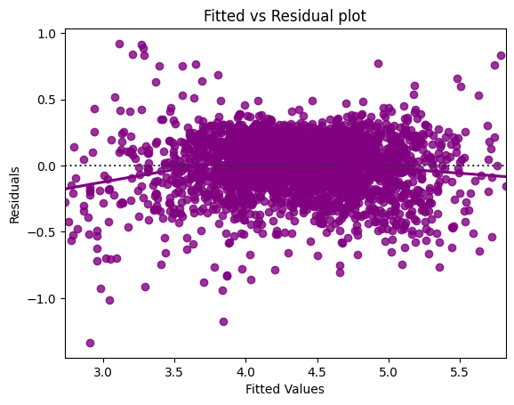

```python
# let's plot the fitted values vs residuals

sns.residplot(
    data=data_pred, x="fitted", y="residuals", color="purple", lowess=True
)
plt.xlabel("Fitted Values")
plt.ylabel("Residuals")
plt.title("Fitted vs Residual plot")
plt.show()
```

- The scatter plot shows the distribution of residuals (errors) vs fitted values (predicted values).
- There is no pattern in the plot above. Hence, the assumptions of linearity and independence are satisfied.

### Test for Normality

**How to check normality?**

- The shape of the histogram of residuals can give an initial idea about the normality.
- It can also be checked via a Q-Q plot of residuals. If the residuals follow a normal distribution, they will make a straight line plot, otherwise not.
- Other tests to check for normality includes the Shapiro-Wilk test.
  - Null hypothesis: Residuals are normally distributed
  - Alternate hypothesis: Residuals are not normally distributed

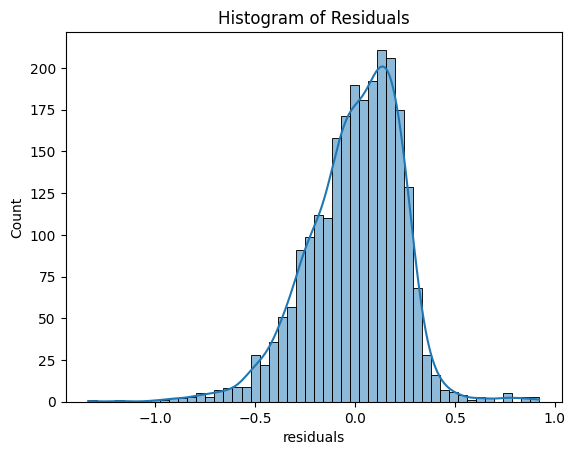

```python
# checking the shape of the histogram
sns.histplot(data_pred['residuals'], kde=True)
plt.title('Histogram of Residuals')
plt.show()
```

The Histogram seeems to have a bell shape

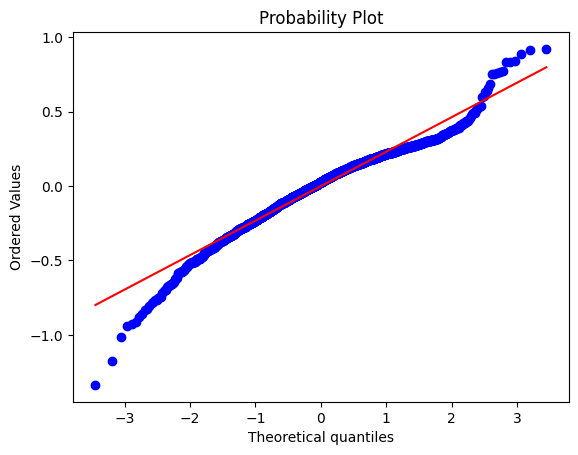

```python
# Checking the Q-Q plot

import pylab
import scipy.stats as stats

stats.probplot(data_pred['residuals'], dist="norm", plot=pylab)
plt.show()
```

The residuals follow a straight line except for the tails

```python
# Shapiro-Wilk test
# Null hypothesis: Residuals are normally distributed
# Alternate hypothesis: Residuals are not normally distributed

from scipy.stats import shapiro
stats.shapiro(data_pred['residuals'])
```

```
ShapiroResult(statistic=0.9696391727491132, pvalue=3.316185618633274e-22)
```

- Since p-value < 0.05, the residuals are not normal as per the Shapiro-Wilk test.
- However, as an approximation, we can accept this distribution as close to being normal.
- **So, the assumption is satisfied.**

### TEST FOR HOMOSCEDASTICITY

**How to check for homoscedasticity?**

- The residual vs fitted values plot can be looked at to check for homoscedasticity. In the case of heteroscedasticity, the residuals can form an arrow shape or any other non-symmetrical shape.
- The goldfeldquandt test can also be used. If we get a p-value > 0.05 we can say that the residuals are homoscedastic. Otherwise, they are heteroscedastic.
  - Null hypothesis: Residuals are homoscedastic
  - Alternate hypothesis: Residuals have heteroscedasticity

```python
import statsmodels.stats.api as sms
from statsmodels.compat import lzip

name = ["F statistic", "p-value"]
test = sms.het_goldfeldquandt(data_pred["residuals"], X_train4)
lzip(name, test)
```

```
[('F statistic', 1.0471982176623287), ('p-value', 0.2127931628016726)]
```

Since p-value > 0.05, we can say that the residuals are homoscedastic. So, this assumption is satisfied.

## Predictions on Test data

```python
# predictions on the test set

prediction= olsmod_afterP.predict(X_test4)

data_prediction_test = pd.DataFrame()
data_prediction_test['actual'] = y_test
data_prediction_test['predicted'] = prediction

data_prediction_test.sample(10, random_state=1)
```

|  | actual | predicted |
| --- | --- | --- |
| 1995 | 4.566741 | 4.441240 |
| 2341 | 3.696103 | 3.983543 |
| 1913 | 3.592093 | 3.566698 |
| 688 | 4.306495 | 4.108930 |
| 650 | 4.522115 | 5.135950 |
| 2291 | 4.259294 | 4.376885 |
| 40 | 4.997685 | 5.450331 |
| 1884 | 3.875359 | 3.974368 |
| 2538 | 4.206631 | 3.988735 |
| 45 | 5.380450 | 5.349389 |

- We can observe here that our model has returned pretty good prediction results, and the actual and predicted values are comparable.
- We can also visualize comparison result as a bar graph for a sample of 25 records

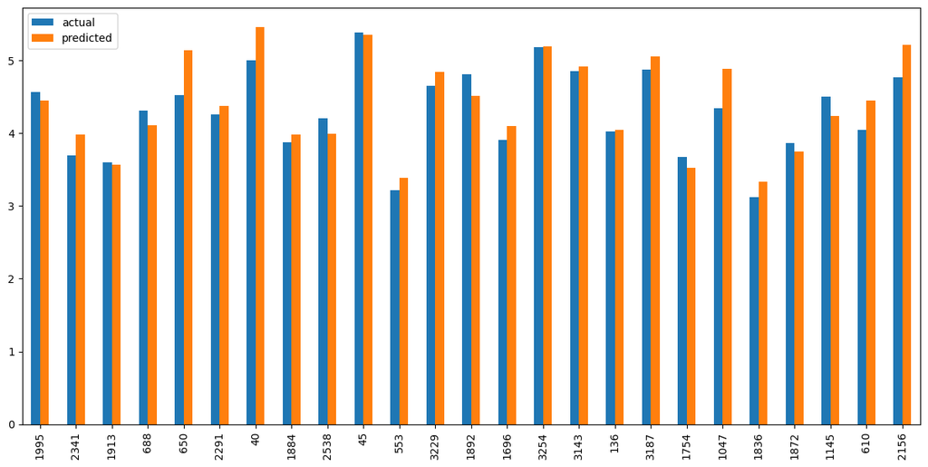

```python
Final_prediction= data_prediction_test.sample(25, random_state=1)
Final_prediction.plot(kind="bar", figsize=(15, 7))
plt.show()
```

## Final Model

```python
olsModel_final = sm.OLS(y_train, X_train4).fit()
print(olsModel_final.summary())
```

```
                              OLS Regression Results
=================================================================================
Dep. Variable:     normalized_used_price   R-squared:                       0.837
Model:                               OLS   Adj. R-squared:                  0.836
Method:                    Least Squares   F-statistic:                     951.5
Date:                   Sat, 09 Nov 2024   Prob (F-statistic):               0.00
Time:                           02:01:35   Log-Likelihood:                 66.343
No. Observations:                   2417   AIC:                            -104.7
Df Residuals:                       2403   BIC:                            -23.62
Df Model:                             13
Covariance Type:               nonrobust
========================================================================================
                           coef    std err          t      P>|t|      [0.025      0.975]
----------------------------------------------------------------------------------------
const                   -0.6191      0.078     -7.888      0.000      -0.773      -0.465
main_camera_mp           0.0246      0.002     15.697      0.000       0.022       0.028
selfie_camera_mp         0.0219      0.002     14.580      0.000       0.019       0.025
int_memory               0.0008      0.000      4.420      0.000       0.000       0.001
ram                      0.0222      0.004      4.950      0.000       0.013       0.031
normalized_new_price     0.3764      0.011     33.501      0.000       0.354       0.398
weight_log               0.4872      0.016     31.236      0.000       0.457       0.518
brand_name_Celkon       -0.1380      0.054     -2.552      0.011      -0.244      -0.032
brand_name_Micromax     -0.0656      0.028     -2.367      0.018      -0.120      -0.011
brand_name_Nokia         0.1234      0.031      3.942      0.000       0.062       0.185
brand_name_Others       -0.0399      0.014     -2.798      0.005      -0.068      -0.012
brand_name_Sony         -0.0849      0.031     -2.767      0.006      -0.145      -0.025
os_Others               -0.1481      0.029     -5.145      0.000      -0.205      -0.092
4g_yes                   0.0534      0.014      3.816      0.000       0.026       0.081
==============================================================================
Omnibus:                      207.683   Durbin-Watson:                   1.938
Prob(Omnibus):                  0.000   Jarque-Bera (JB):              405.878
Skew:                          -0.572   Prob(JB):                     7.32e-89
Kurtosis:                       4.649   Cond. No.                     1.01e+03
==============================================================================

Notes:
[1] Standard Errors assume that the covariance matrix of the errors is correctly specified.
[2] The condition number is large, 1.01e+03. This might indicate that there are
strong multicollinearity or other numerical problems.
```

```python
# checking model performance on train set (seen 70% data)

print("Training Performance\n")
olsmodel_final_train_perf = model_performance_regression(
    olsModel_final, X_train4, y_train
)
olsmodel_final_train_perf
```

```
Training Performance
```

|  | RMSE | MAE | R-squared | Adj. R-squared | MAPE |
| --- | --- | --- | --- | --- | --- |
| 0 | 0.235419 | 0.183057 | 0.837326 | 0.836378 | 4.414261 |

```python
# checking model performance on test set (seen 30% data)

print("Test Performance\n")
olsmodel_final_test_perf = model_performance_regression(
    olsModel_final, X_test4, y_test
)
olsmodel_final_test_perf
```

```
Test Performance
```

|  | RMSE | MAE | R-squared | Adj. R-squared | MAPE |
| --- | --- | --- | --- | --- | --- |
| 0 | 0.24427 | 0.188341 | 0.834568 | 0.832302 | 4.609658 |

## Actionable Insights and Recommendations

Additional data regarding customer demographics (age, gender, income, etc.) can be collected and analyzed to gain better insights into the preferences of customers across different price segments.